# Color recipes

SPDS, uni.kn

2022 11 30

[figure not shown]

This vignette shows how various color-related tasks can be solved by the tools provided by **unikn**. (For a general introduction of the **unikn** colors, color palettes, and color functions, see the vignette on Colors and color functions. The vignette on text provides information on creating text boxes and decorations.)

The following recipes illustrate how plotting functions in R can use the colors and color palettes provided by the **unikn** package. Additional examples show how we can use the `seecol()`, `usecol()`, `newpal()`, and `grepal()` functions for solving color-related tasks.

Please install and/or load the **unikn** package to get started:

```r
# install.packages('unikn')  # install unikn from CRAN client
library('unikn')             # loads the package
```

## Using colors in **base** R

**Task:** Using **unikn** colors in visualizations created by **base** R graphics.

When creating **base** R visualizations (e.g., using `plot()` for creating a scatterplot), use the `usecol()` function in combination with any color palette (e.g., `pal_unikn`) as the `col` argument:

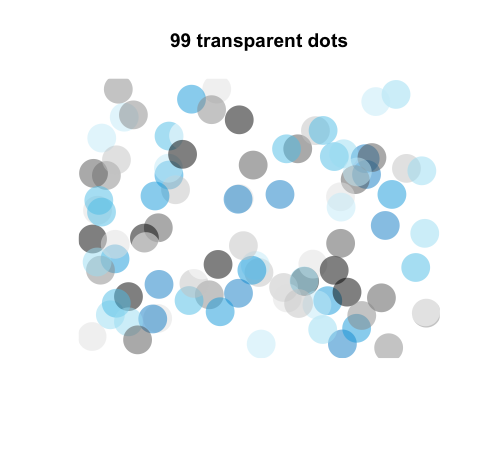

```r
my_col <- usecol(pal_unikn, alpha = .50)  # with transparency

plot(x = runif(99), y = runif(99), type = "p",
     pch = 16, cex = 4,
     col = my_col,
     main = "99 transparent dots", axes = FALSE, xlab = NA, ylab = NA)
```

## Using colors in **ggplot2**

**Task:** Using **unikn** colors in visualizations created by the **ggplot2** package.

When using the `ggplot()` function of **ggplot2** (e.g., for creating an area plot), use the `usecol()` function for defining a color palette (of the desired length and transparency) that is then provided as the `values` of the `scale_color_manual()` or `scale_fill_manual()` functions:

1. Wrap the desired color palette in the `usecol()` function of **unikn**.
2. Provide this palette as the `values` of the **ggplot2** functions `scale_color_manual()` or `scale_fill_manual()`.

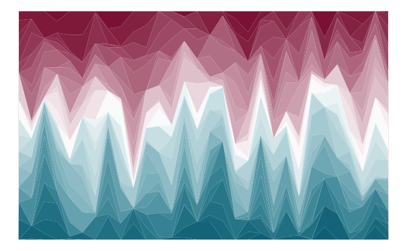

```r
# 0. Create data: ----

# Example based on https://www.r-graph-gallery.com/137-spring-shapes-data-art/
n <- 50
groups <- 1:n
df <- data.frame()

set.seed(3)

for (i in seq(1:30)){
  data = data.frame(matrix(0, n, 3))
  data[, 1] <- i
  data[, 2] <- sample(groups, nrow(data))
  data[, 3] <- prop.table(sample(c(rep(0, 100), c(1:n)), nrow(data)))
  df = rbind(df, data)}

names(df) <- c("X","Group","Y")
df$Group <- as.factor(df$Group)
df <- df[c(2, 1, 3)]
df <- df[order(df$X, df$Group) , ]
rownames(df) <- NULL

my_data <- df

# 1. Colors: ----

# A. using RColorBrewer:
# library(RColorBrewer)

# cur_col <- brewer.pal(11, "Paired")
# cur_col <- colorRampPalette(cur_col)(n)
# cur_col <- cur_col[sample(c(1:length(cur_col)), size = length(cur_col))]  # randomize

# B. using unikn colors:
library(unikn)

# Mix a color gradient:
cur_col <- usecol(c(Bordeaux, "white", Petrol), n = n)
# cur_col <- cur_col[sample(c(1:length(cur_col)), size = length(cur_col))]  # randomize

# 2. Plotting: ----

library(ggplot2)

ggplot(my_data, aes(x = X, y = Y, fill = Group)) +
  geom_area() +
  scale_fill_manual(values = cur_col) +
  theme_void() +
  theme(legend.position = "none")
```

## Viewing and comparing color palettes

**Task:** Inspect (the colors and details of) a color palette.

For easily viewing an individual color palette (e.g., provided by the new HCL color palettes `hcl.pals()` of R), use the palette as the `pal` argument of the `seecol()` function:

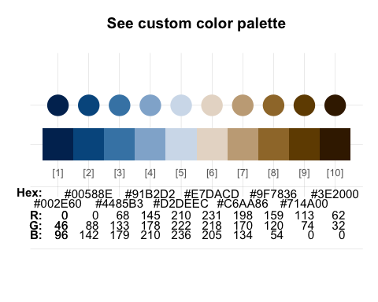

```r
col_pal <- hcl.colors(10, "Vik")  # some color palette

seecol(col_pal)  # see its colors and details
```

Note that the other arguments of the `seecol()` function — especially `n` and `alpha` — can modify the palette (in the same ways as the `usecol()` function).

**Task:** Compare (the colors and range of) multiple color palettes.

For comparing multiple color palettes (e.g., 20 random color palettes of `hcl.pals()`), provide them as a list in the `pal` argument of the `seecol()` function.

For instance, let’s create and compare a set of 20 random HCL palettes:

- Generate random HCL palettes (and save them as a list):

```r
# Parameters:
n_col <-  8   # colors in each palette
n_pal <- 20   # length(hcl.pals())
ptype <- NULL # c("diverging", "divergingx", "qualitative", "sequential")[4]

s_pal <- sample(x = hcl.pals(type = ptype), size = n_pal, replace = FALSE)
s_pal <- sort(s_pal)

# Initialize:
t_lbl <- paste0("See ", n_pal, " random HCL color palettes (n = ", n_col, ")")
l_pal <- vector("list", n_pal)  # lists of palettes

# Loop:
for (i in 1:n_pal){

  l_pal[[i]] <- hcl.colors(n = n_col, palette = s_pal[i])

}
```

- Use `seecol()` for comparing multiple color palettes:

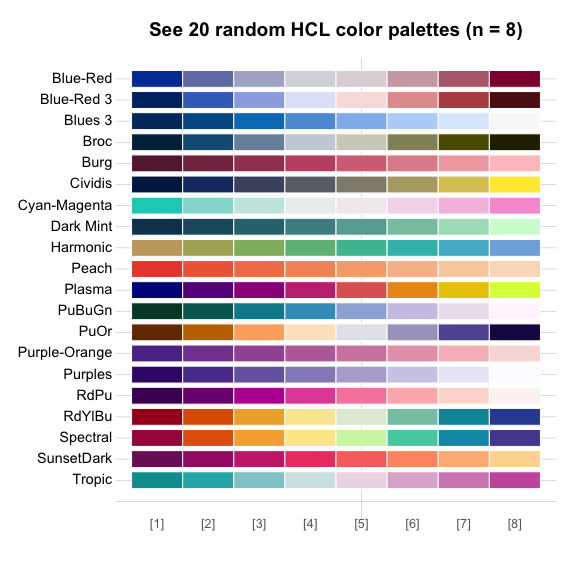

```r
seecol(pal = l_pal,
       pal_names = s_pal,
       col_brd = "white", lwd_brd = 1,
       main = t_lbl)
```

## Finding similar colors

**Task:** Find a color that is similar to some given color.

Use the `simcol()` function for finding (and plotting/seeing) similar colors:

```r
simcol("forestgreen")
```

```
#>    forestgreen    chartreuse4         green4      olivedrab     olivedrab4
#>  "forestgreen"  "chartreuse4"       "green4"    "olivedrab"   "olivedrab4"
#>     palegreen4   springgreen4
#>   "palegreen4" "springgreen4"
```

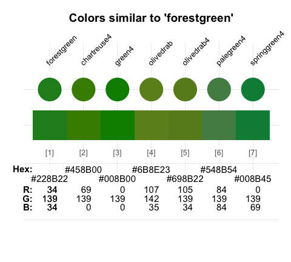

The `simcol()` function compares a require target color (`col_target`) with a set of candidate colors (`col_candidates`, set to `colors()` by default). Color similarity is defined in terms of the colors’ pair-wise distances in RGB values. If this distance falls below some tolerance value(s) (`tol`), the corresponding `col_candidates` are shown and returned. Thus, increasing the tolerance value yields a wider range of colors:

```r
simcol(col_target = "orange", col_candidates = pal_unikn_pref, tol = 150)
```

```
#>    orange     Pinky     Peach    Signal  Bordeaux
#>  "orange" "#E0607E" "#FEA090" "#EFDC60" "#8E2043"
```

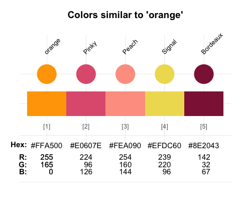

Specifying a vector of three `tol` values compares RGB dimensions in the order of their rank. This allows for more fine-grained similarity searches:

```r
simcol(col_target = Seeblau, tol = c(20, 20, 80))
```

```
#>         Seeblau    lightskyblue   lightskyblue2         skyblue        skyblue1
#>       "#59C7EB"  "lightskyblue" "lightskyblue2"       "skyblue"      "skyblue1"
#>        skyblue2      steelblue1
#>      "skyblue2"    "steelblue1"
```

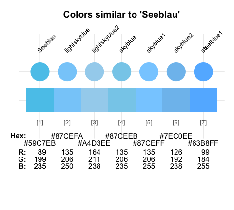

## Creating new color palettes

**Task:** Create a new color palette (with color names).

The general steps for creating an new color palette (with dedicated color names) are:

1. Choose some colors (and their R color names, or as RGB/HEX/HCL values, e.g., from sites like https://www.schemecolor.com).
2. Define the colors as an R vector (of type character).
3. Define optional color names as a second R vector (of type character).
4. Use the `newpal()` command to define the new color palette (as an R data frame or vector).

Once a new palette has been defined, it can be inspected (with `seecol()`) or further modified and used in visualizations (with `usecol()`):

[figure not shown]

```r
# 1. Choose colors:
# Google logo colors (from <https://www.schemecolor.com/google-logo-colors.php>)

# 2. Define colors (as vector):
color_google <- c("#4285f4", "#34a853", "#fbbc05", "#ea4335")

# 3. Define color names (as vector):
names_google <- c("blueberry", "sea green", "selective yellow", "cinnabar")

# 4. Define color palette:
pal_google <- newpal(color_google, names_google)

# Inspect color palette:
seecol(pal_google,
       col_brd = "white", lwd_brd = 8,
       main = "Colors of the Google logo")
```

The vignette on Institutional colors provides additional examples for defining color palettes.

## Finding colors by name

**Task:** Find colors by matching their names to a pattern (as a regular expression).

Here are some additional examples for using the `grepal()` function for finding colors by their names (or a pattern):

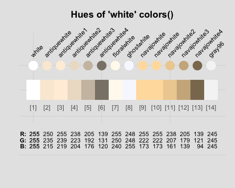

```r
# Get color palettes matching a pattern:
pal_1 <- grepal("orange", plot = FALSE)
pal_2 <- grepal("olive", plot = FALSE)
pal_3 <- grepal("white", plot = FALSE)

# See individual palettes:
# seecol(pal_1, main = "Hues of 'orange' colors()")
# seecol(pal_2, main = "Hues of 'olive' colors()")
seecol(pal_3, main = "Hues of 'white' colors()", col_bg = "grey90")
```

Providing a list of color palettes to the `pal` argument of the `seecol()` function allows comparing multiple color palettes:

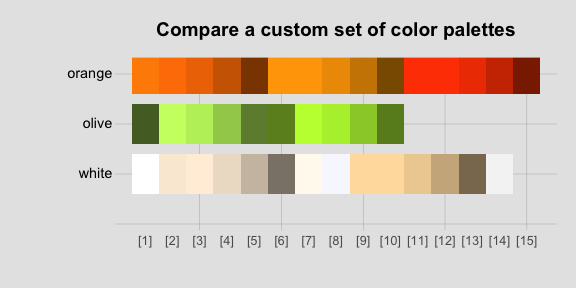

```r
# See multiple color palettes:
seecol(pal = list(pal_1, pal_2, pal_3),
       pal_names = c("orange", "olive", "white"),
       col_bg = "grey90")
```

Let’s compare different types of “blue”, “orange”, and “purple or violet” provided by the **grDevices** vector of named `colors()` with various shades of “blau”, “pink”, “peach” and “bordeaux” provided by **unikn** color palettes:

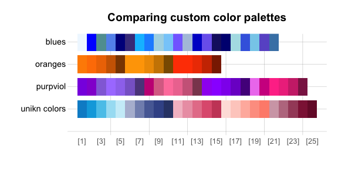

```r
# Search colors() with specific patterns (in their names):
blues    <- grepal("blue$", plot = FALSE)   # ending on "blue"
oranges  <- grepal("orange", plot = FALSE)  # containing "orange"
purpviol <- grepal("purple|violet", plot = FALSE)  # containing "purple" or "violet"

# Search unikn palettes for color names:
blaus_1 <- grepal("blau", pal_unikn, plot = FALSE)
blaus_2 <- grepal("blau", pal_karpfenblau, plot = FALSE)
pinks <- grepal("pink", pal_pinky, plot = FALSE)
peach <- grepal("peach", pal_peach, plot = FALSE)
baux  <- grepal("bordeaux", pal_bordeaux, plot = FALSE)

# See multiple color palettes:
seecol(list(blues, oranges, purpviol,
            c(blaus_1, blaus_2, pinks, peach, baux)),
       pal_names = c("blues", "oranges", "purpviol", "unikn colors"),
       main ="Comparing custom color palettes")
```